# annex

## Solvency and Financial Report of Insurance Firms for the Bank of England

(Analysed by: Syarmine Shah)

### **Background:**

This report is part of technical assignment for Analyst - Systems, Change and Banking Data team (PRA Strategy, Risk & Operations) (009533) role at the Bank of Egnland.

This report contains the results of data analysis assignment of insurance firms across the United Kingdom under the Bank of England and Prudential Regulation Authority (PRA).

In total, there are 325 firms in the dataset with 8 business profile metrics and 9 underwriting metrics, ranging from 2016 and 2020 period. The following are the metrics in the dataset:

| General | Underwriting |
| --- | --- |
| Gross_claims_incurred_(£m) | NWP_(£m) |
| Gross_BEL_(inc.*TPs_as_whole,_pre-TMTP)*(£m) | SCR_(£m) |
| Net_BEL_(inc.*TPs_as_a_whole,_pre-TMTP)*(£m) | EoF_for_SCR_(£m) |
| Pure_net_claims_ratio | SCR_coverage_ratio |
| Net_expense_ratio | GWP_(£m) |
| Net_combined_ratio | Total_assets_(£m) |
| Pure_gross_claims_ratio | Total_liabilities_(£m) |
| Gross_expense_ratio | Excess_of_assets_over_liabilities_(£m)_[=_equity] |
| Gross_combined_ratio |  |

I would like Bank of England for this opportunity be a part of this assessment and analysing firm-level insurance dataset. The report covers the requirements for technical assessment assigned by the Bank of England.

This report sets out my findings on firm's profile and provides thematic observations that support improvements in supervisory resource allocation management. PRA Supervision teams will use individual firm responses to inform their supervisory strategy, which may result in follow-up discussions and actions.

## 1. Firms Analysis

To analyse the firm size, the following metrics are selected

- Total Assets(TA)
- Gross Written Premium (GWP)
- Net Written Premium (NWP)

From 2016 to 2020 period, the following table summarise the sum of each of the metrics

[output not shown]

- From 2016 to 2020, the following is a trend line across 5 years period by TA, GWP and NWP.

[figure not shown]

- In 2020, at firm level, the following shows the top 10 firms based on TA, GWP, and NWP.

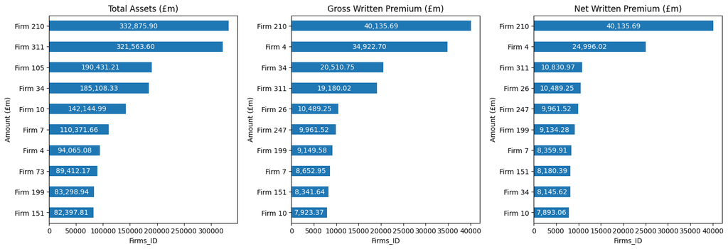

- The firms dataset are further analysed using concentration and distributions measures (CDMs) as recommended by [International Monetary Fund 2019: Financial Soundness Indicator Compilation Guide](https://www.imf.org/en/Data/Statistics/FSI-guide)

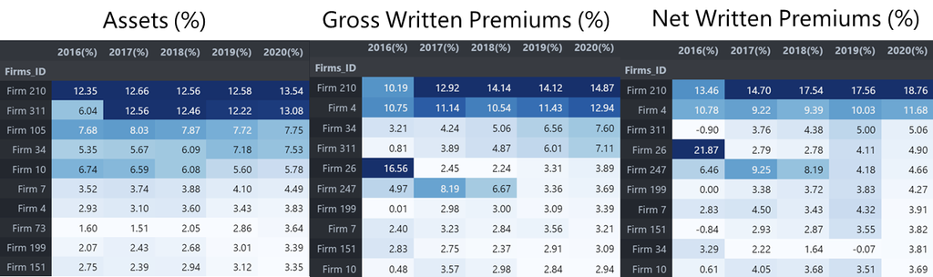

### Key Insights

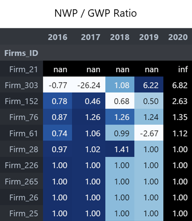

## 2. Business Trends

The following shows top 10 firm year-on-year across 2016 to 2020.

**2.1 Gross claims incurred**

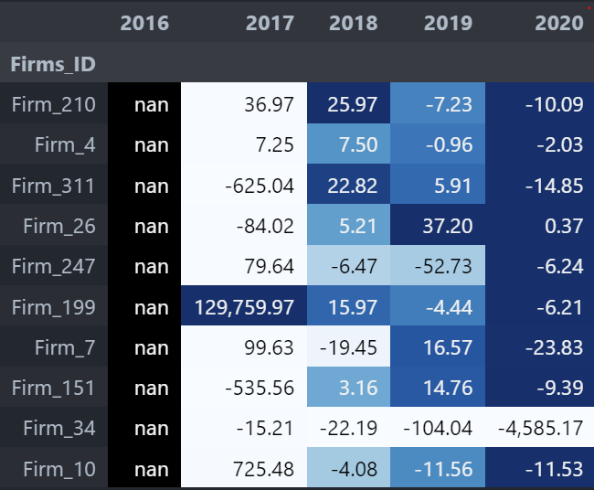

**2.2 Pure Gross Claims Ratio**

- Across 5 year period, there are notable variation of the pure gross claim ratio across the 325 firms, with 285 firms are within 0% to 62%, excluding outlier (see next section). Generally there pure gross claim ratio is below 100% across the 5 years, except year 2020, where the top 10 firms are above 100% ratio.

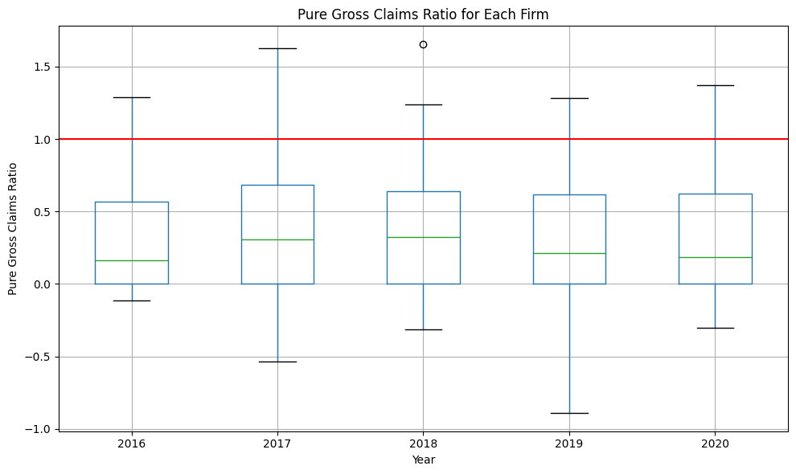

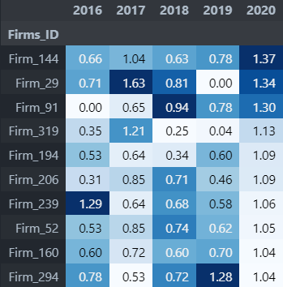

[figure not shown]

**2.3 Net Combined Ratio**

- Across 5 year period, there are notable variation of the net combined ratio across the 325 firms, with 285 firms are within 0% to 97.9% in year 2020, excluding outlier (see next section). Generally there net combined ratio are below 100% across the 5 years, except year 2020, where the top 10 firms are above 100% ratio.

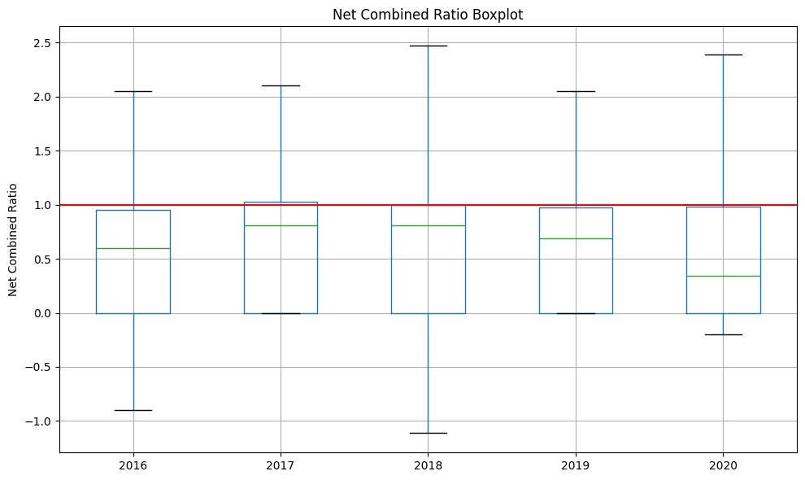

- In 2020, Firm 97, Firm 21 and Firm 29, have a net combined ratio of 239%%, 230%% and 215% with a variation in YoY increment of 139%, 238% and 183% each respectively.Image below is the net combined ratio values.

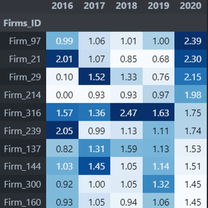

- The following is the YoY of the net combined ratio as mentioned.

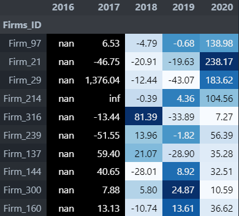

**2.4 Solvency Coverage Ratio**

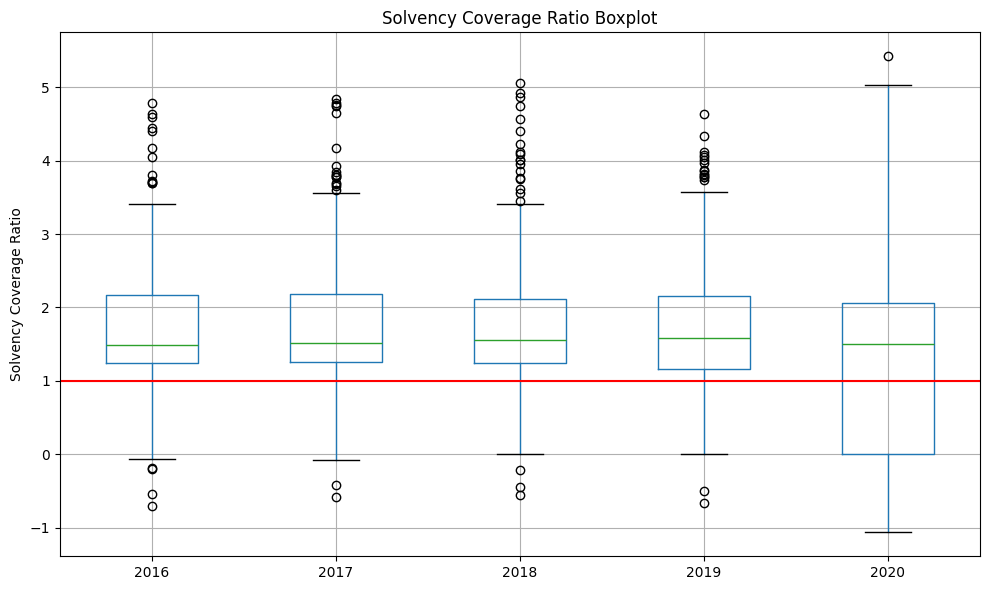

- - In 2020, Firm 20, Firm 62 and Firm 13, have a solvency coverage ratio of 543%, 503% and 459%% with a variation in YoY increment of 42%, 49% and 16% each respectively.Image below is the solvency coverage ratios sorted by Year 2020.

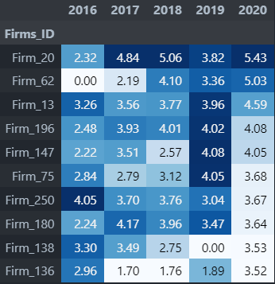

- The following is the YoY of the solvency coverage ratio as mentioned.

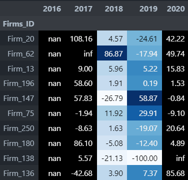

## 3. Outliers

The following methods are taken to identify outliers within this dataset

- The use of concentration and distribution measures
- Identification using boxplot

**3.1 Pure Gross Claim Ratio**

- The following boxplot are generated when the code is run for the first time. The boxplot can't be visualised as there is an extreme value in year 2019.

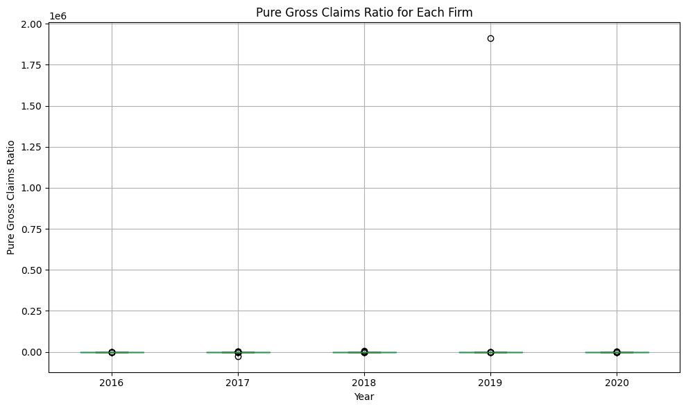

- Using the describe method, there is notable extreme outliers within the dataset. The outliers is from the datapoint in 2019, where the maximum value of pure gross claim ratio is at 1,911,108 from Firm 188. There are 40 firms that are excluded and identified as outliers.

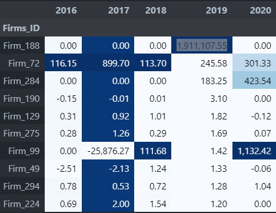

**3.2 Net Combined Ratio**

- The following boxplot are generated when the code is run.

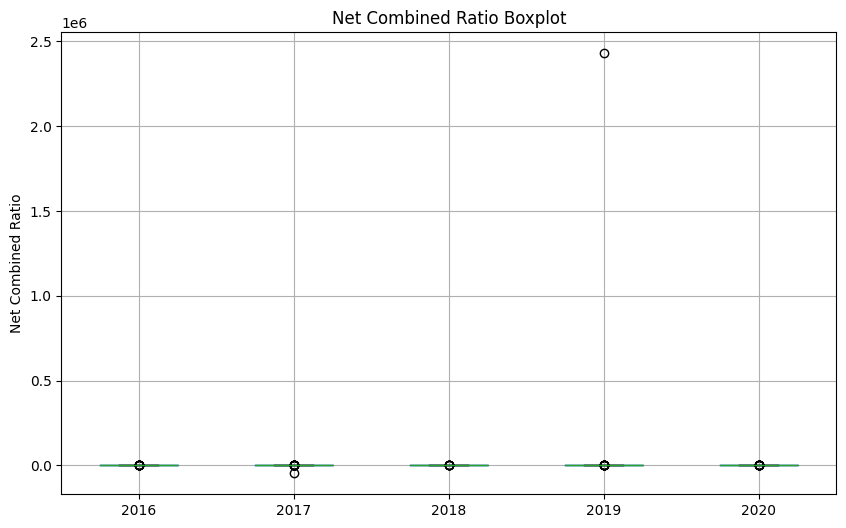

- Using describe method, there is extereme data value in the dataset in year 2019, with a net combined ratio of 2,430,023. The firm identified is Firm 188.

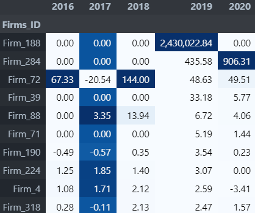

**3.3 Solvency Coverage Ratio**

- The following boxplot are generated when the code is run showing extreme outliers in year 2017.

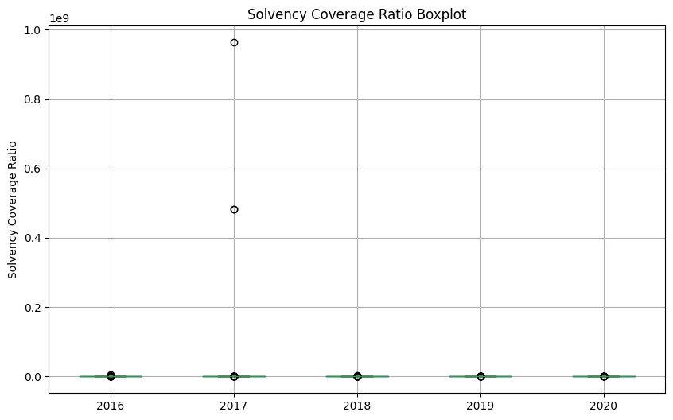

- Using describe method, there is extereme data value in the dataset in year 2017, with a solvency coverage ratio 963,584,000.00. Upon sorting by year 2017, the firm identified is Firm 216. The solvency coverage ratio are followed closely by Firm 1, Firm 131, and Firm 127 with 481,792,000%, 481,792,000% and 182,412% each respectively.

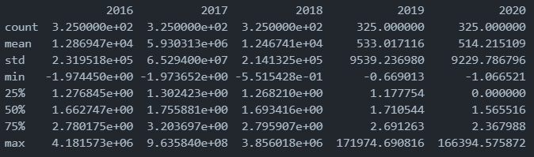

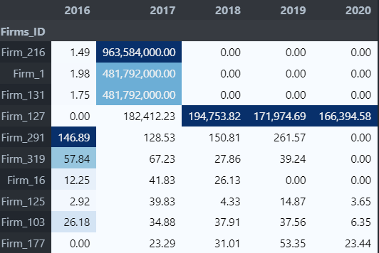

- The data for Firm 127 the following years from 2018 to 2020 shows a close average ranging from 166,394% to 194,753%.

# Annex

The following section details out the Python script for this report:

```python
# script made by Muhammad Syarmine Bin Mohd Shah
# Feels free to contact me at syarmineshah@yahoo.com for feedback
# import required libraries and packages
import pandas as pd
import numpy as np
import matplotlib.pyplot as plt
import seaborn as sns
import openpyxl as xl # import the dataset using pandas pd.read_excel with openpyxl package
import plotly_express as px
```

### Getting and structuring the data

```python
# get data from github
url = "https://github.com/Syarmine/Portfolio/raw/main/BoE%20Assignment/Data%20for%20technical%20assessment.xlsx"
dict_df = pd.read_excel(url,
                header=0, #add indexing without including the dataset
                sheet_name=[0,1]) # get sheet 1 and sheet 2

df = dict_df.get(0)
df_1 = dict_df.get(1)
```

```python
# check the data shape
print(df.shape)
print(df_1.shape)

# check the Dataset 1 head
df.head()
```

```
(326, 41)
(326, 46)
```

|  | Unnamed: 0 | NWP (£m) | NWP (£m) .1 | NWP (£m) .2 | NWP (£m) .3 | NWP (£m) .4 | SCR (£m) | SCR (£m).1 | SCR (£m).2 | SCR (£m).3 | ... | Total liabilities (£m) | Total liabilities (£m).1 | Total liabilities (£m).2 | Total liabilities (£m).3 | Total liabilities (£m).4 | Excess of assets over liabilities (£m) [= equity] | Excess of assets over liabilities (£m) [= equity].1 | Excess of assets over liabilities (£m) [= equity].2 | Excess of assets over liabilities (£m) [= equity].3 | Excess of assets over liabilities (£m) [= equity].4 |
| --- | --- | --- | --- | --- | --- | --- | --- | --- | --- | --- | --- | --- | --- | --- | --- | --- | --- | --- | --- | --- | --- |
| 0 | NaN | 2016YE | 2017YE | 2018YE | 2019YE | 2020YE | 2016YE | 2017YE | 2018YE | 2019YE | ... | 2016YE | 2017YE | 2018YE | 2019YE | 2020YE | 2016YE | 2017YE | 2018YE | 2019YE | 2020YE |
| 1 | Firm 1 | -13779.815629 | 0 | 0 | 0 | 0 | 1085.360139 | 0.0 | 0 | 0 | ... | 69696.557128 | 0 | 0 | 0 | 0 | 2031.035937 | 4.81792 | 0 | 0 | 0 |
| 2 | Firm 2 | 28.178059 | 26.865049 | 25.064438 | 23.226445 | 21.718558 | 10.190314 | 10.113572 | 9.495235 | 8.146471 | ... | 8.526315 | 9.585694 | 8.596011 | 6.932901 | 8.526285 | 33.39118 | 40.637281 | 50.621614 | 57.602326 | 29.6524 |
| 3 | Firm 3 | 0 | 75.609681 | 70.578732 | 78.432782 | 85.73583 | 322.955115 | 363.782327 | 362.290859 | 394.295982 | ... | 926.065667 | 1016.401689 | 974.7339 | 1032.497033 | 1214.913306 | 583.650604 | 558.916856 | 566.073253 | 598.338699 | 540.065747 |
| 4 | Firm 4 | 22344.199923 | 23963.910709 | 25760.390158 | 25512.748836 | 24996.021042 | 16573.6448 | 16332.7488 | 17103.616 | 17219.24608 | ... | 50485.0106 | 56618.706223 | 62935.244436 | 64005.547967 | 71237.710999 | 16919.338528 | 16415.923037 | 18249.584833 | 20795.97601 | 22827.370034 |

5 rows × 41 columns

```python
# check the Dataset 2 head
df_1.head()
```

|  | Unnamed: 0 | Gross claims incurred (£m) | Gross claims incurred (£m).1 | Gross claims incurred (£m).2 | Gross claims incurred (£m).3 | Gross claims incurred (£m).4 | Gross BEL (inc. TPs as whole, pre-TMTP) (£m) | Gross BEL (inc. TPs as whole, pre-TMTP) (£m).1 | Gross BEL (inc. TPs as whole, pre-TMTP) (£m).2 | Gross BEL (inc. TPs as whole, pre-TMTP) (£m).3 | ... | Gross expense ratio | Gross expense ratio.1 | Gross expense ratio.2 | Gross expense ratio.3 | Gross expense ratio.4 | Gross combined ratio | Gross combined ratio.1 | Gross combined ratio.2 | Gross combined ratio.3 | Gross combined ratio.4 |
| --- | --- | --- | --- | --- | --- | --- | --- | --- | --- | --- | --- | --- | --- | --- | --- | --- | --- | --- | --- | --- | --- |
| 0 | NaN | 2016YE | 2017YE | 2018YE | 2019YE | 2020YE | 2016YE | 2017YE | 2018YE | 2019YE | ... | 2016YE | 2017YE | 2018YE | 2019YE | 2020YE | 2016YE | 2017YE | 2018YE | 2019YE | 2020YE |
| 1 | Firm 1 | 0 | 0.046674 | 0 | 0 | 0 | 0 | 7.674468 | 0 | 0 | ... | 0 | 56.813725 | 0 | 0 | 0 | 0 | 68.215239 | 0 | 0 | 0 |
| 2 | Firm 2 | 39.241067 | 35.948249 | 29.002244 | 0 | 0 | 163.597907 | 195.529933 | 201.533018 | 0 | ... | 0.743265 | 0.963451 | 0.814588 | 0 | 0 | 0.945394 | 1.126744 | 0.939197 | 0 | 0 |
| 3 | Firm 3 | 0 | 0 | 0 | 0 | 0 | 0 | 0 | 0 | 0 | ... | 0 | 0 | 0 | 0 | 0 | 0 | 0 | 0 | 0 | 0 |
| 4 | Firm 4 | 17.125976 | 75.535951 | 119.426995 | 35.884204 | 6.567988 | -18.297099 | 22.640145 | 80.383783 | 99.569129 | ... | 0.14393 | 0.147519 | 0.092971 | 0.054781 | -0.546237 | 0.848032 | 1.474778 | 1.727968 | 1.208823 | -10.736084 |

5 rows × 46 columns

```python
# check for missing values for Dataset 1
df.isnull().sum()
```

```
Unnamed: 0                                             1
NWP (£m)                                               0
NWP (£m) .1                                            0
NWP (£m) .2                                            0
NWP (£m) .3                                            0
NWP (£m) .4                                            0
SCR (£m)                                               0
SCR (£m).1                                             0
SCR (£m).2                                             0
SCR (£m).3                                             0
SCR (£m).4                                             0
EoF for SCR (£m)                                       0
EoF for SCR (£m).1                                     0
EoF for SCR (£m).2                                     0
EoF for SCR (£m).3                                     0
EoF for SCR (£m).4                                     0
SCR coverage ratio                                     0
SCR coverage ratio.1                                   0
SCR coverage ratio.2                                   0
SCR coverage ratio.3                                   0
SCR coverage ratio.4                                   0
GWP (£m)                                               0
GWP (£m).1                                             0
GWP (£m).2                                             0
GWP (£m).3                                             0
GWP (£m).4                                             0
Total assets (£m)                                      0
Total assets (£m).1                                    0
Total assets (£m).2                                    0
Total assets (£m).3                                    0
Total assets (£m).4                                    0
Total liabilities (£m)                                 0
Total liabilities (£m).1                               0
Total liabilities (£m).2                               0
Total liabilities (£m).3                               0
Total liabilities (£m).4                               0
Excess of assets over liabilities (£m) [= equity]      0
Excess of assets over liabilities (£m) [= equity].1    0
Excess of assets over liabilities (£m) [= equity].2    0
Excess of assets over liabilities (£m) [= equity].3    0
Excess of assets over liabilities (£m) [= equity].4    0
dtype: int64
```

```python
# check for missing values for Dataset 2
df_1.isnull().sum()
```

```
Unnamed: 0                                        1
Gross claims incurred (£m)                        0
Gross claims incurred (£m).1                      0
Gross claims incurred (£m).2                      0
Gross claims incurred (£m).3                      0
Gross claims incurred (£m).4                      0
Gross BEL (inc. TPs as whole, pre-TMTP) (£m)      0
Gross BEL (inc. TPs as whole, pre-TMTP) (£m).1    0
Gross BEL (inc. TPs as whole, pre-TMTP) (£m).2    0
Gross BEL (inc. TPs as whole, pre-TMTP) (£m).3    0
Gross BEL (inc. TPs as whole, pre-TMTP) (£m).4    0
Net BEL (inc. TPs as a whole, pre-TMTP) (£m)      0
Net BEL (inc. TPs as a whole, pre-TMTP) (£m).1    0
Net BEL (inc. TPs as a whole, pre-TMTP) (£m).2    0
Net BEL (inc. TPs as a whole, pre-TMTP) (£m).3    0
Net BEL (inc. TPs as a whole, pre-TMTP) (£m).4    0
Pure net claims ratio                             0
Pure net claims ratio.1                           0
Pure net claims ratio.2                           0
Pure net claims ratio.3                           0
Pure net claims ratio.4                           0
Net expense ratio                                 0
Net expense ratio.1                               0
Net expense ratio.2                               0
Net expense ratio.3                               0
Net expense ratio.4                               0
Net combined ratio                                0
Net combined ratio.1                              0
Net combined ratio.2                              0
Net combined ratio.3                              0
Net combined ratio.4                              0
Pure gross claims ratio                           0
Pure gross claims ratio.1                         0
Pure gross claims ratio.2                         0
Pure gross claims ratio.3                         0
Pure gross claims ratio.4                         0
Gross expense ratio                               0
Gross expense ratio.1                             0
Gross expense ratio.2                             0
Gross expense ratio.3                             0
Gross expense ratio.4                             0
Gross combined ratio                              0
Gross combined ratio.1                            0
Gross combined ratio.2                            0
Gross combined ratio.3                            0
Gross combined ratio.4                            0
dtype: int64
```